# HW4

2023-05-23

## Question 1

Using damages.csv, estimate a quadratic damage function relating the dollar value of damages to the change in global mean temperature. Omit an intercept term; damages by construction must equal zero when there is no climate change. Plot your estimated damage function, overlaid with a scatterplot of the underlying data

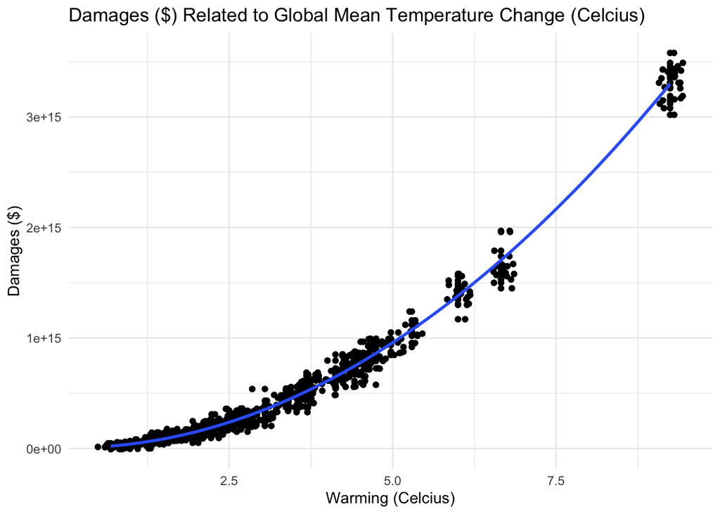

```r
#opening the data
damage_data <- read.csv("damages.csv")
warming_data <- read.csv("warming.csv")

#creating our damage function
quad_dmg <- lm(damages~0 + warming+I(warming^2), damage_data)

#plotting our results over the scatterplot
ggplot(damage_data, aes(warming, damages)) + geom_point() + geom_jitter(width=.2) + stat_smooth(method = "lm", formula = y ~ x + I(x^2), size = 1) + ggtitle("Damages ($) Related to Global Mean Temperature Change (Celcius)") +labs(x="Warming (Celcius)", y="Damages ($)") + theme_minimal()
```

## Question 2

Use warming.csv and your estimated damage function to predict damages in each year underthe baseline climate trajectory and under the pulse scenario. Make four plots:

*Plot 1* damages over time without the pulse

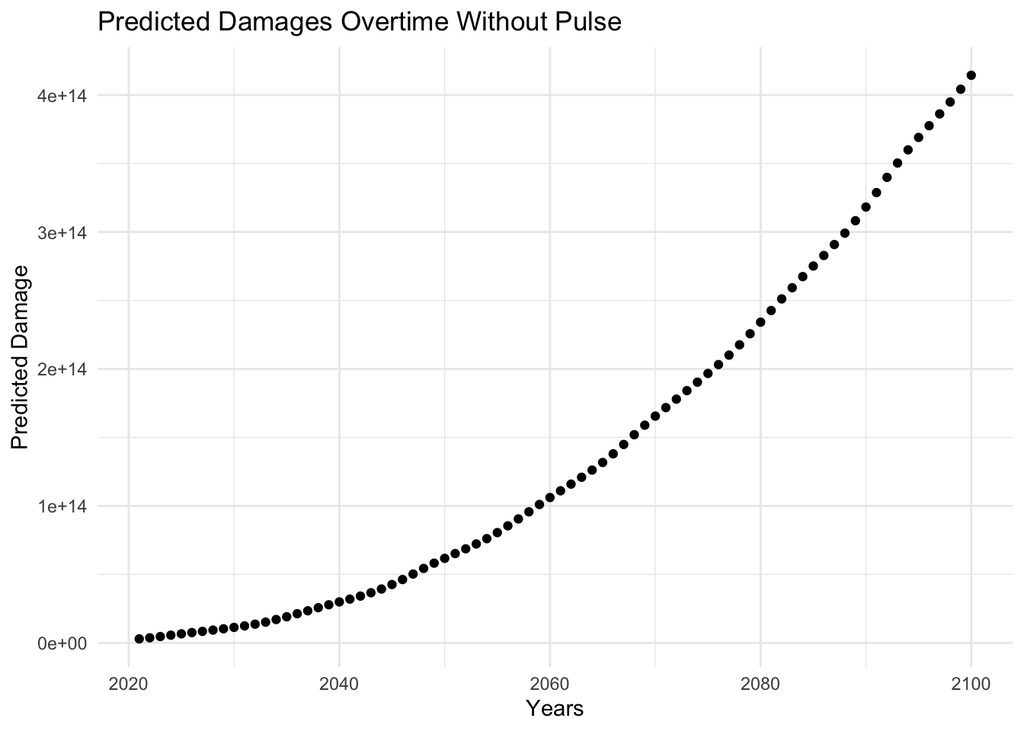

```r
base_warm <- tibble(warming=warming_data$warming_baseline)

predicted_baseline_dmg <- data.frame(predict_damage = predict(quad_dmg, newdata=tibble(warming=warming_data$warming_baseline))) %>%
                mutate(years=warming_data$year)

ggplot(predicted_baseline_dmg, aes(years, predict_damage)) + geom_point() + ggtitle("Predicted Damages Overtime Without Pulse")+ labs(x="Years", y="Predicted Damage")+theme_minimal()
```

*Plot 2* damages over time with the pulse

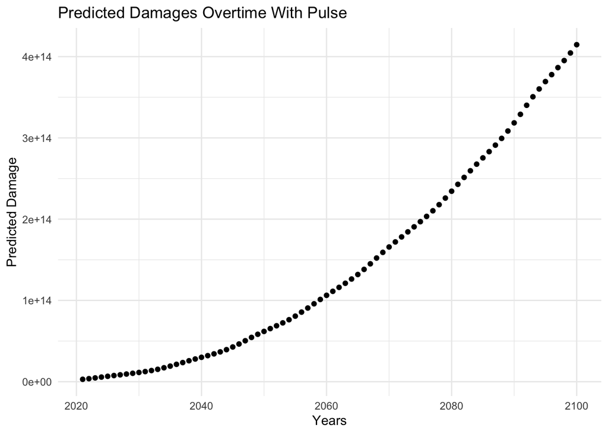

```r
pulse_warm <- tibble(warming=warming_data$warming_pulse)
predicted_pulse_dmg <- data.frame(predict_damage = predict(quad_dmg, newdata=pulse_warm)) %>%
                mutate(years=warming_data$year)

ggplot(predicted_pulse_dmg, aes(years,predict_damage)) + geom_point() + ggtitle("Predicted Damages Overtime With Pulse")+ labs(x="Years", y="Predicted Damage")+theme_minimal()
```

*Plot 3* the difference in damages over time that arises from the pulse

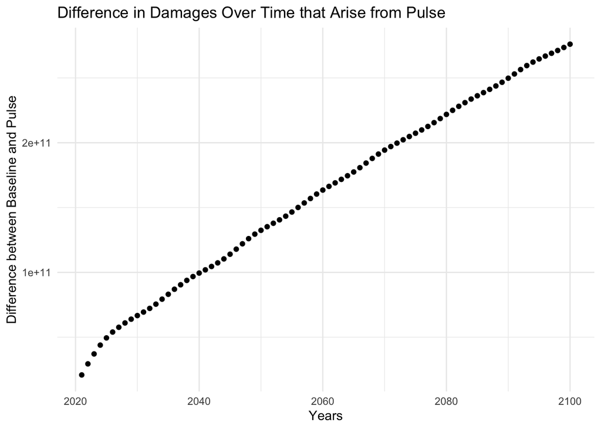

```r
diff_damage <- cbind.data.frame(year=warming_data$year, diff=(predicted_pulse_dmg$predict_damage - predicted_baseline_dmg$predict_damage))

ggplot(diff_damage, aes(year, diff)) + geom_point() + labs(y="Difference between Baseline and Pulse", x="Years")+ggtitle("Difference in Damages Over Time that Arise from Pulse") + theme_minimal()
```

*Plot 4* the difference in damages over time from the pulse per ton of CO2 (you can assume that each ton of the pulse causes the same amount of damage)

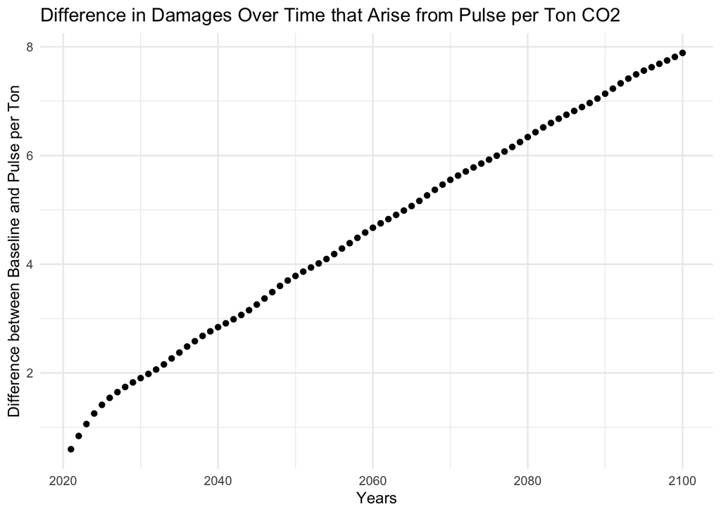

```r
diff_damage_per_ton <- cbind.data.frame(year=warming_data$year, diff_dmg=(predicted_pulse_dmg$predict_damage - predicted_baseline_dmg$predict_damage)/(35*10^9))

ggplot(diff_damage_per_ton, aes(year, diff_dmg)) + geom_point() + labs(y="Difference between Baseline and Pulse per Ton", x="Years") + ggtitle("Difference in Damages Over Time that Arise from Pulse per Ton CO2") + theme_minimal()
```

## Question 3

The SCC is defined as the present discounted value of the stream of future damages caused by one additional ton of CO2.1 The Obama Administration used a discount rate of 3% to discount damages. The recent EPA update uses a discount rate that changes over time, but starts at 2%. Calculate and make a plot of the SCC (y-axis) against the discount rate (x-axis) for discount rates ranging from 1% to 8%.

```r
present_dmg <- diff_damage_per_ton %>% filter(year=="2023")
df_dmgs = data.frame()
discount <- seq(.01,.08, .01)
years <- 2021:2100

for(i in 1:length(discount)){
for(j in 1:length(years)){
     future_discounted_dmg <- sum(diff_damage_per_ton$diff_dmg)/(1+discount[i])^(years-2023)[j]
 }
   df_discount <- data.frame("rates" = discount[i], future_discounted_dmg)
   df_dmgs <- rbind(df_dmgs,df_discount)
}
 df_dmgs
```

```
##   rates future_discounted_dmg
## 1  0.01           171.2873767
## 2  0.02            80.2154296
## 3  0.03            37.8446800
## 4  0.04            17.9847338
## 5  0.05             8.6078583
## 6  0.06             4.1487715
## 7  0.07             2.0133545
## 8  0.08             0.9836531
```

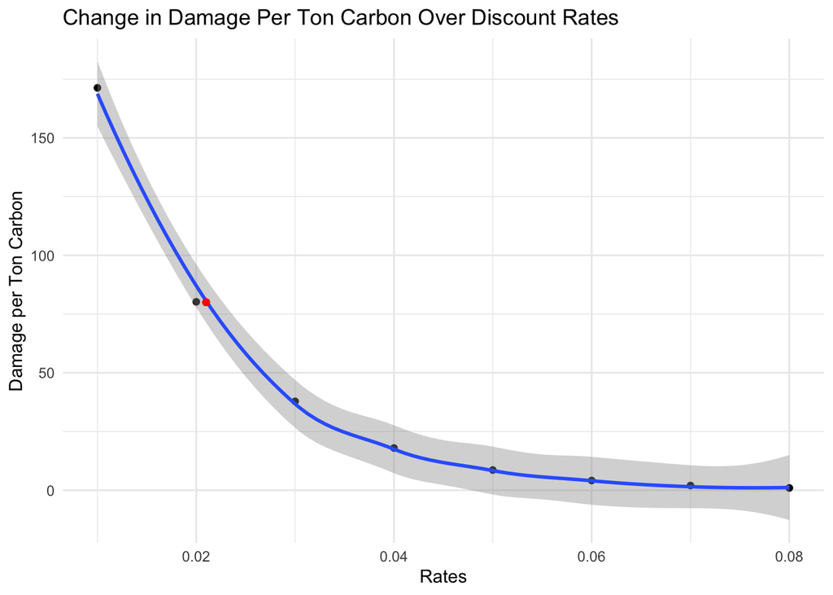

```r
ggplot(df_dmgs, aes(rates, future_discounted_dmg)) + geom_point() + geom_smooth() + theme_minimal() + ggtitle("Change in Damage Per Ton Carbon Over Discount Rates") + labs(x="Rates", y="Damage per Ton Carbon") + geom_point(aes(x= .021, y =80), colour = "red")
```

## Question 4

The National Academies of Sciences, Engineering, and Medicine advised the government in a 2017 report to use the Ramsey Rule when discounting within the SCC calculation, a recommendation the EPA considered. Recall the Ramsey Rule: r = ρ + ηg Using ρ = 0.001, η = 2, and g = 0.01, what is the SCC? Locate this point on your graph from above.

See red point located on graph above for SCC at .021.

```r
.001+(2*.01)
```

```
## [1] 0.021
```

## Question 5

Now suppose there are two possible climate policies that can be pursued. Policy A is business as usual emissions, without any substantial climate change mitigation. Policy B is to take immediate and strong action on climate change.

Use these facts: *If you undertake Policy A there are two possible outcomes. Either warming will occur as in the “baseline” (i.e. “no-pulse”) dataset above (this happens with probability 0.5) or warming each year will be 1.5 times that in the “baseline” dataset (with probability 0.5).* Under Policy B, warming will continue until 2050 as in the “baseline” dataset, and then will stabilize at 1.29 degrees and stay that way forever. *Society is risk neutral* Use a discount rate of 2%

What is the expected present value of damages up to 2100 under Policy A?

```r
# warming_data$warming_increased <- warming_data$warming_baseline*1.5
# damages_A <- data.frame(predict_damage_stable = predict(quad_dmg, newdata=tibble(warming=warming_data$warming_increased))) %>% mutate(predicted_baseline_dmg) %>% filter(years %in% (2023:2100))
#
# # damage_A_total <- (sum(predicted_baseline_dmg$predict_damage)/(1+.02)^(2100-2023) *.5) +
# #  (sum(predicted_baseline_dmg$predict_damage)/(1+.02)^(2100-2023) *.5 * 1.5)
#
# df_dmgs_A = data.frame()
#
# years_A <- 2023:2100
# for(i in 1:length(years_A)){
# # damage_A_total <- data.frame(sum(damages_A$predict_damage)/(1+.02)^(years_A[i]-2023)*.5 + sum(damages_A$predict_damage_stable)/(1+.02)^(years_A[i]-2023)*.5)
# damage_A_base <- damages_A$predict_damage/(1+.02)^(years_A[i]-2023)*.5
# damage_A_inc  <- damages_A$predict_damage_stable/(1+.02)^(years_A[i]-2023)*.5
# }
#
# sum(damage_A_base) + sum(damage_A_inc)
```

```r
damages_A_baseline <- data.frame(predict_damage_baseline = predict(quad_dmg, newdata=tibble(warming=warming_data$warming_baseline *.5)))

damages_A_increased <- data.frame(predict_damage_increased = predict(quad_dmg, newdata=tibble(warming=warming_data$warming_baseline*1.5*.5)))

damages_A <- mutate(damages_A_baseline, damages_A_increased, year=warming_data$year) %>%
  filter(year %in% (2023:2100))

df_dmgs_A = data.frame()

years_A <- 2023:2100
for(i in 1:length(years_A)){
# damage_A_total <- data.frame(sum(damages_A$predict_damage)/(1+.02)^(years_A[i]-2023)*.5 + sum(damages_A$predict_damage_stable)/(1+.02)^(years_A[i]-2023)*.5)
damage_A_base <- damages_A$predict_damage_baseline/(1+.02)^(years_A[i]-2023)
damage_A_inc  <- damages_A$predict_damage_increased/(1+.02)^(years_A[i]-2023)
}

total_damages_A <- sum(damage_A_base) + sum(damage_A_inc)
total_damages_A
```

```
## [1] 2.000432e+15
```

What is the expected present value of damages up to 2100 under Policy B?

```r
warming_data$warming_stable <- ifelse(warming_data$year>=2050, 1.29, warming_data$warming_baseline)

damages_B <- data.frame(predict_damage = predict(quad_dmg, newdata=tibble(warming=warming_data$warming_stable))) %>% mutate(years=warming_data$year) %>% filter(years %in% (2023:2100))

df_dmgs_B = data.frame()

years_B <- 2023:2100
for(i in 1:length(years_B)){
damage_B_stream <- damages_B$predict_damage/(1+.02)^(years_B[i]-2023)
# df_damage_B <- data.frame(damage_B_total)
# df_dmgs_B <- rbind(df_dmgs_B,df_damage_B)
}

total_damages_B <- sum(damage_B_stream)
total_damages_B
```

```
## [1] 8.318965e+14
```

Suppose undertaking Policy A costs zero and undertaking Policy B costs X. How large could X be for it to still make economic sense to pursue Policy B instead of Policy A?

```r
# X < Da - Db
total_damages_A - total_damages_B
```

```
## [1] 1.168535e+15
```